# Notebook 01

## Using R

We will be using R and RMarkdown this semester to both apply the statistical models that we learn to data and to run simulations that support our theoretical results. If you have never used R before that is completely fine! There’s a little bit of a learning curve, but we are mostly either use only relatively simple code or run code where I have already done the difficult work for you. Let’s see a few examples of how R works here before moving on to today’s material.

The text on a white background (like this!) is just plain text that you can freely edit. Text that is on a grey background, like the one below, is actual code. You can run it by clicking on the green “play” button in the upper right-hand corner of the box. Everything here can be edited. Fill in your favorite number below and then run the following code to create a new variable with your number attached to it:

```r
fav_number <- 8
```

You should notice that your new variable shows up in the Environment tab in the upper right-hand corner of the RStudio window. I will do my best to explain new R concepts when they first arise. But, please ask questions in class about anything you want to know more about!

## Taking the Mean

In the notes today we looked at taking the sample mean of a dataset. Let’s read in a dataset where we can take the mean of one of the variable. Here, we have the code to read in a dataset of the heights and birth-dates of players on rosters from the 2023/2024 Premier League season. A few heights are missing, and we remove these before continuing:

```r
pl <- read_csv("../data/premier_league.csv")
pl <- filter(pl, !is.na(height))
pl
```

```
## # A tibble: 640 × 5
##    player          team            bdate      height position
##    <chr>           <chr>           <date>      <dbl> <chr>
##  1 Adam Smith      AFC Bournemouth 1991-04-29    180 DF
##  2 Alex Scott      AFC Bournemouth 2003-08-21    178 MF
##  3 Antoine Semenyo AFC Bournemouth 2000-01-07    185 FW
##  4 Ben Greenwood   AFC Bournemouth 2003-02-20    180 DF
##  5 Cameron Plain   AFC Bournemouth 2001-09-24    182 GK
##  6 Chris Mepham    AFC Bournemouth 1997-11-05    191 DF
##  7 Dango Ouattara  AFC Bournemouth 2002-02-11    177 FW
##  8 Darren Randolph AFC Bournemouth 1987-05-12    188 GK
##  9 David Brooks    AFC Bournemouth 1997-07-08    173 FW
## 10 Dominic Solanke AFC Bournemouth 1997-09-14    187 FW
## # ℹ 630 more rows
```

The variable `pl` contains the entire dataset. In order to access a specific column of the data, we use the dataset name followed by a dollar sign and the name of the column of interest. So, to get the heights, we would do `pl$height`. R has the function `mean()` that takes the sample mean of a set of numbers. Below, we put these together to get the sample mean of the player heights. The results are in centimeters.

```r
mean(pl$height)
```

```
## [1] 182.7891
```

How can we see this in terms of the random sampling that we have in our theoretical notes? Well, that’s actually a bit complex and philosophical. In a sense, we are not sampling from something but rather observing the entire league. The easiest way to think about this is to imagine that we are observing one set of players that was generated be some complex genetic and social interactions that led to these particular players being in the Premier League during the 2023/2024 season. The number above is an estimate of what the average height would be if we ran back time and produced many different versions of our current world. Yes, that’s why I say that this gets quickly philosophical! We will talk more about this throughout the semester.

We can take a mean of a specific part of the dataset by selecting only some of the heights. For example, here is the code to only select heights from the “AFC Bournemouth” team:

```r
mean(pl$height[pl$team == "AFC Bournemouth"])
```

```
## [1] 182.129
```

Here are all of the teams in the dataset:

```r
table(pl$team)
```

```
##
##         AFC Bournemouth              Arsenal FC             Aston Villa
##                      31                      33                      29
##            Brentford FC  Brighton & Hove Albion              Burnley FC
##                      31                      36                      33
##              Chelsea FC          Crystal Palace              Everton FC
##                      38                      32                      28
##               Fulham FC            Liverpool FC              Luton Town
##                      28                      39                      29
##         Manchester City       Manchester United        Newcastle United
##                      28                      34                      35
##       Nottingham Forest        Sheffield United       Tottenham Hotspur
##                      32                      32                      32
##         West Ham United Wolverhampton Wanderers
##                      30                      30
```

In the code block below, find the average height of another team of your choosing.

```r
# Question 01
mean(pl$height[pl$team == "Chelsea FC"])
```

```
## [1] 183.5
```

Think about how does this compare to the heights of the league as a whole and the AFC Bournemouth team specifically. Could you think of a way of characterizing the magnitude of these differences?

## Simulation

Now, let’s see how we can use R to simulate the relationships between different random variables. We were able to derive some of these theoretically. The simulations help to verify that our calculations are correct and to help build further intuition.

The code below uses the `rnorm` function to generate a set of 25 samples from a normal distribution with mean 3 and standard deviation 1.

```r
x <- rnorm(n = 25, mean = 3, sd = 1)
x
```

```
##  [1] 3.013948 1.024255 3.884162 3.075333 4.877930 3.216253 3.536846 5.348164
##  [9] 2.015935 3.645800 2.252459 5.106550 3.735063 2.135822 3.292703 4.122049
## [17] 2.633866 3.105815 3.249440 3.267781 2.071117 3.298670 3.019848 4.551137
## [25] 3.777889
```

We can take the mean of these with the same `mean` function that we used above. Try that in the code below:

```r
# Question 02
mean(x)
```

```
## [1] 3.330353
```

Compare your results with another student. You will see that your results are not exactly the same because you have different random samples (in contrast, the means of the heights in the previous section should have been exactly the same).

We want to show that the distribution of the sample mean in this case appears to follow a normal distribution with mean 3 and variance 1 / n = 1/25. In order to do this we need to repeat the previous simulation a large number of times and store the sample mean each iteration. Here is the code to do that using a for loop:

```r
N <- 100000
xbar <- rep(0, N)
for (j in seq_along(xbar))
{
  x <- rnorm(n = 25, mean = 3, sd = 1)
  xbar[j] <- mean(x)
}
```

Then, in order to see the simulated distribution, we can draw a histogram with a curve on top of it. Note that R uses the standard deviation to parameterize the normal distribution, so we will use the square root of the expected variance: 1/5).

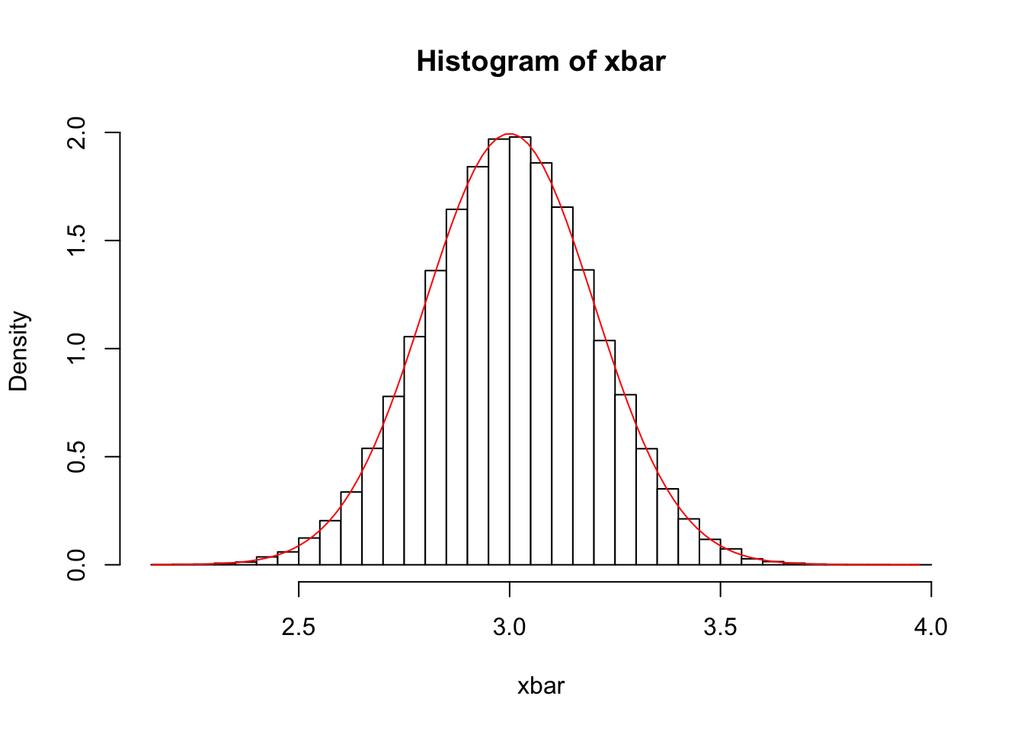

```r
hist(xbar, breaks = 50, probability = TRUE, col = "white")
curve(dnorm(x, 3, 1/5),
      from = min(xbar), to = max(xbar), add = TRUE, col = "red")
```

You should notice that the red line approximately follows the empirical distribution given by the histogram.

The central limit theorem says that we should have a similar result for any sampling distribution with a finite mean and finite variance. In the code below, run another simulation for the sample mean of 25 i.i.d. samples. But this time, use a different distribution. Some options are: `runif`, `rbeta`, and `rgamma`. You may need to look up the parameter names for the distribution.

```r
# Question 03
N <- 100000
xbar <- rep(0, N)
for (j in seq_along(xbar))
{
  x <- rbeta(n = 25, shape1 = 0.6, shape2 = 2)
  xbar[j] <- mean(x)
}
```

Now, create a histogram and overlay the expected normal distribution. This may require looking up the properties of the random variable.

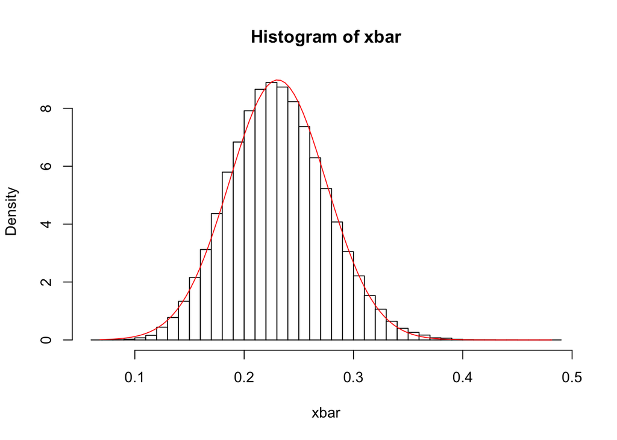

```r
# Question 04
hist(xbar, breaks = 50, probability = TRUE, col = "white")
curve(dnorm(x, 0.6 / 2.6, 1/5 * sqrt((0.6 * 2) / (2.6^2 * (3.6)))),
      from = min(xbar), to = max(xbar), add = TRUE, col = "red")
```

If you have some extra time, see if reducing the sample size to a smaller number begins to show the non-normality of the sample mean. You should see that you can get some skew with smaller samples, but the CLT kicks in extremely fast.